## 0.1 Learning objectives

1. Identify the components of **Vector data** objects.
2. Read Spatial data from **local Shapefiles** using the `read_sf()` function from the `{sf}` package.

## 0.2 Prerequisites

This lesson requires the following packages:

```r
if(!require('pacman')) install.packages('pacman')

pacman::p_load(malariaAtlas,
               ggplot2,
               cholera,
               sf)

pacman::p_load_gh("afrimapr/afrilearndata",
                  "wmgeolab/rgeoboundaries")
```

## 0.3 Introduction

In the previous lesson we learned how to get **Vector Data**, which is the most common format of Spatial data used in GIS, from **external** repositories. We also learned and how to relate **Vector data** types that are needed by GIS software to create *Thematic maps*.

But, How can we create more *Thematic maps* from *external* Spatial data that is only available in our **local files**? Or how to *distribute* it to colleagues through e-mail or GitHub?

In this lesson we are going dive into **Vector data** components and how to read it from **local files**!

## Delving into vector data

All these *simple feature* (`sf`) objects are also of class **data.frame**.

```r
class(africapitals)
```

```
## [1] "sf"         "data.frame"
```

All the *Spatial data* that we used until now used to make *Thematic maps* have two main components: A **header** and a **data frame**.

For example, for a *Dot map* we used a the `africapitals` object:

```r
africapitals
```

```
## Simple feature collection with 51 features and 4 fields
## Geometry type: POINT
## Dimension:     XY
## Bounding box:  xmin: -17.48 ymin: -29.31 xmax: 47.51 ymax: 36.84
## Geodetic CRS:  WGS 84
## First 10 features:
##       capitalname              countryname     pop iso3c             geometry
## 280         Abuja                  Nigeria  178462   NGA    POINT (7.17 9.18)
## 308         Accra                    Ghana 2029143   GHA    POINT (-0.2 5.56)
## 382   Addis Abeba                 Ethiopia 2823167   ETH   POINT (38.74 9.03)
## 996       Algiers                  Algeria 2029936   DZA   POINT (3.04 36.77)
## 1584 Antananarivo               Madagascar 1463754   MDG POINT (47.51 -18.89)
## 2193       Asmara                  Eritrea  578860   ERI  POINT (38.94 15.33)
## 3102       Bamako                     Mali 1342519   MLI  POINT (-7.99 12.65)
## 3233       Bangui Central African Republic  547668   CAF   POINT (18.56 4.36)
## 3265       Banjul                   Gambia   34388   GMB  POINT (-16.6 13.46)
## 4551       Bissau            Guinea-Bissau  404119   GNB  POINT (-15.6 11.87)
```

The first line of the **header** details the dimensions of the *Simple feature* (`sf`) object.

```
Simple feature collection with 51 features and 4 fields
```

- The number of *features* are the number of rows in the **data frame**.
- The number of *fields* are equal to the number of columns in the **data frame** minus one. It **excludes** the *last one* called **geometry**.

### Geometries

If we explore the **data frame** associated with the Spatial data objects, we identify that all of them have a **geometry** column at the end:

```
            geometry
   POINT (7.17 9.18)
   POINT (-0.2 5.56)
  POINT (38.74 9.03)
  POINT (3.04 36.77)
POINT (47.51 -18.89)
 POINT (38.94 15.33)
 POINT (-7.99 12.65)
  POINT (18.56 4.36)
 POINT (-16.6 13.46)
 POINT (-15.6 11.87)
```

The text that appears below the **geometry** column its also detailed in the second line of the **header** of the output:

```
Geometry type: POINT
```

Now, identify which *Geometry* is detailed in other Spatial data objects used until now for a:

1. *Choropleth map*, and

```r
africountries
```

2. *Physical features*

```r
afrihighway
```

These **Geometries** (Point, Polygon and Lines) are types of **Vector data**.

Which of the following options of *vector data* types:

1. `"polygon_geometry"`
2. `"point_geometry"`
3. `"line_geometry"`

…corresponds to each of these *thematic map* scenarios?

Please enter the name of the geometry and not the letter associated to it.

Compare the number of COVID-19 cases in each province of Angola during the year 2021, filling each of the provinces with a color scale directly proportional to the number of cases.

Visualize the distribution of hospital and clinical health facilities in Senegal, using geographical coordinates recorded in field with GPS devices.

Visualize the urban water supply networks in the city of Cape Town, South Africa.

## 0.4 Recap : Thematic maps and Vector data

All *Thematic maps* need **Vector data** in a GIS software to be plotted:

- Choropleth maps use *Polygon* geometry.
- Dot maps use *Point* geometry.
- Physical features in a map use *Line* geometry.

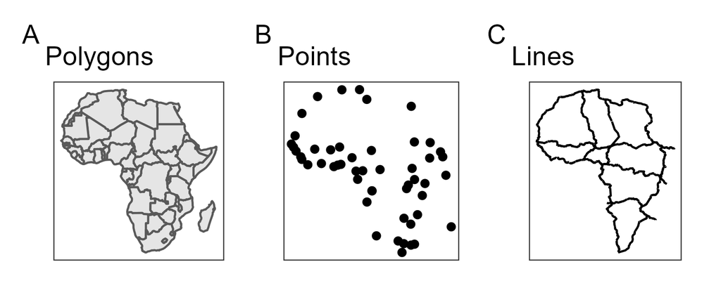

## 0.5 From Local files

We can **read** *Vector data* from **local files** with a `.shp` extension like `sle_adm3.shp`, available inside the `ch06_basic_geospatial_viz/data/boundaries/` folder, in three steps:

1. Identify the **working directory** of the **R chunks** of this `.Rmd` file:

```r
getwd()
```

```
## [1] "/Users/kendavidn/Dropbox/graph_courses/course_projects/further-data-analysis-with-r-wp/ch06_basic_geospatial_viz/lessons"
```

- The default *working directory* inside **R chunks** is the *document directory* of the **Rmd file**.
- It is **different** from the *R console* and the *R project*, if any.
2. Find the **file path** up to the `.shp` filename, *relative to* the working directory of the R chunks:

```r
"../data/boundaries/sle_adm3.shp"
```

3. Then, use the `read_sf()` function from the `{sf}` package as follows:

```r
pacman::p_load(sf)
shape_file <- read_sf("../data/boundaries/sle_adm3.shp")

shape_file
```

[output not shown]

Read the shapefile called `sle_hf.shp` inside the `../data/healthsites/` folder:

The `{sf}` package provides a set of tools for working with geospatial **vectors**, i.e., all the **geometry types** used in the vast majority of geographic research, like polygons, points, and lines.

### 0.5.1 Shapefiles

Files with a `.shp` extension are called **Shapefiles**.

### What are they?

A **Shapefiles** is the most common data format for storing *Vector data*.

A **single shapefile** is actually a *collection* of at least three files - `.shp`, `.shx`, and `.dbf`.

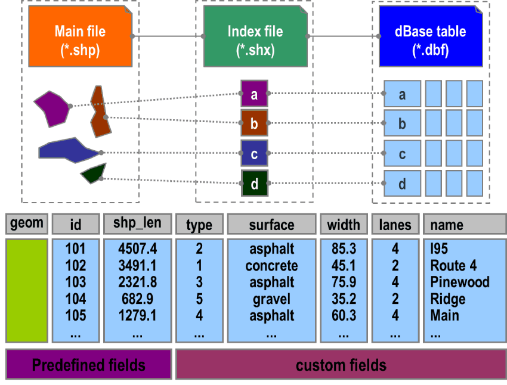

Figure 2. Shapefile is a collection of at least three files.

Each **individual shapefile** can only contain *one vector type* (all points, all lines or all polygons). You will not find a mixture of point, line and polygon objects in a single shapefile.

All of these *sub-component files* must be present in a given directory (folder) for the shapefile to be readable.

As an example, this is a list with the sub-component files of a *Shapefile* called `sle_adm3.shp`. All of them are located in the same `ch06_basic_geospatial_viz/data/boundaries/` folder:

```
## # A tibble: 8 × 1
##   value
##   <chr>
## 1 sle_adm3.CPG
## 2 sle_adm3.dbf
## 3 sle_adm3.prj
## 4 sle_adm3.sbn
## 5 sle_adm3.sbx
## 6 sle_adm3.shp
## 7 sle_adm3.shp.xml
## 8 sle_adm3.shx
```

What is the content inside each file associated with one shapefile?

- **`.shp`**: contains the *geometry* data,
- `.shx`: is a *positional index* of the geometry data that allows to seek forwards and backwards the .shp file,
- `.dbf`: stores the *attributes* for each shape.
- `.prj`: plain text file describing the *projection*,
- `.sbn` and `.sbx`: *spatial index* of the geometry data,
- `.shp.xml`: geospatial *metadata* in XML format.

These *associated files* can be compressed into a ZIP folder to be sent via email or download from a website.

Which of the following options of *component files of Shapefiles*:

1. `"shp"`
2. `"shx"`
3. `"dbf"`

contains the *geometry* data?

stores the *attributes* for each shape?

## 0.6 Wrap up

In this lesson, we have learned to identify the **components** of *Vector data* and how to **read** it from *local Shapefiles* using the *`{sf}`* package.

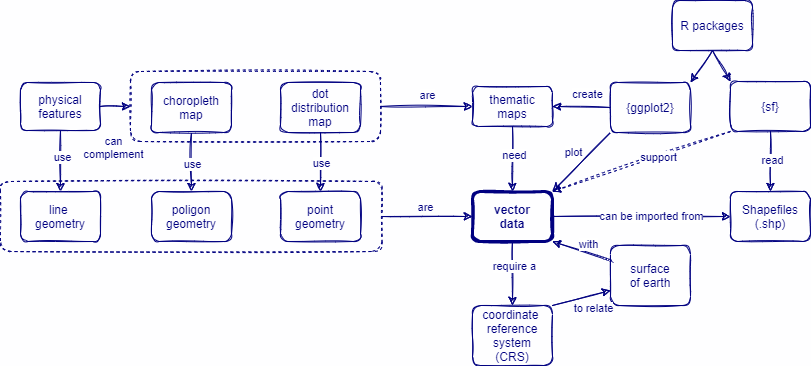

Figure 3. Concept map

In the next lesson we are going dive into **CRS**’s. We are going to learn how to manage the CRS of maps by **zooming in** to an area of interest, **set them up** to external data with coordinates different to longitude and latitude, and **transform** between different coordinate systems!

## Contributors

The following team members contributed to this lesson:

- [ANDREE VALLE CAMPOS](https://thegraphcourses.org/members/avallecam/)  
  R Developer and Instructor, The Graph Network

  Motivated by reproducible science and education.
- [LAURE VANCAUWENBERGHE](https://thegraphcourses.org/members/lolovanco)  
  Data analyst, the GRAPH Network

  A firm believer in science for good, striving to ally programming, health and education.

## References

Some material in this lesson was adapted from the following sources:

- *Seimon, Dilinie. Administrative Boundaries.* (2021). Retrieved 15 April 2022, from https://rspatialdata.github.io/admin_boundaries.html
- *Varsha Ujjinni Vijay Kumar. Malaria.* (2021). Retrieved 15 April 2022, from https://rspatialdata.github.io/malaria.html
- *Batra, Neale, et al. The Epidemiologist R Handbook. Chapter 28: GIS Basics*. (2021). Retrieved 01 April 2022, from https://epirhandbook.com/en/gis-basics.html
- *Lovelace, R., Nowosad, J., & Muenchow, J. Geocomputation with R. Chapter 2: Geographic data in R*. (2019). Retrieved 01 April 2022, from https://geocompr.robinlovelace.net/spatial-class.html
- *Moraga, Paula. Geospatial Health Data: Modeling and Visualization with R-INLA and Shiny. Chapter 2: Spatial data and R packages for mapping*. (2019). Retrieved 01 April 2022, from https://www.paulamoraga.com/book-geospatial/sec-spatialdataandCRS.html

This work is licensed under the [Creative Commons Attribution Share Alike](https://creativecommons.org/licenses/by-sa/4.0/) license.

[figure not shown]